# Firsts vs. Seconds Inaugural Speeches in The U.S. - Words as Emotional Weapons

Carlos Ahumada

May 16th, 2019

# Introduction

Words have the power to make us feel happy, angry, curious, sad, loved, and a large list of other emotions. A right word in the right moment can change our lives or the course of history. In many ocassions, our emotions dictate our actions and shape our support or aversion towards certain things, people, sport teams, or policy positions. In April 2018, Michal Reifen-Tagar and Orly Idan, two researchers at the Interdisciplinary Centre Herzliya, in Israel, published the [paper](https://journals.sagepub.com/doi/10.1177/0956797618772823) “A Rose by Any Other Name? A Subtle Linguistic Cue Impacts Anger and Corresponding Policy Support in Intractable Conflict”. In this study, by measuring the different levels of support and aversion to certain policies in the context of the Israeli-Palestinian conflict, the authors concluded that a good way to use language to reduce tension is to rely, whenever possible, on nouns rather than verbs. The authors found support for the hypothesis that phrasing conflict-relevant policies in noun form (vs. verb form) would reduce anger and impact policy support correspondingly.

# Research Question

Inspired by the work of these academics, the following project aims to find differences between the firsts and seconds inaugural speeches of U.S. Presidents. Are there any substantive differences between these two speeches? Do different term speeches have different emotional content?

# Data

To perform this research I am going to use the U.S. Inaugural Speeches database. The only major modification that was done to it was the removal of the third and fourth term speeches of Franklin D. Roosevelt, the only U.S. President who have served more than two terms.

# Descriptive Analysis

Before getting into to the sentiment analysis and finding out the noun/verb ratio, some general descriptive statistics are provided. The firts chart shows the number of speeches in each one of the categories just for reference.

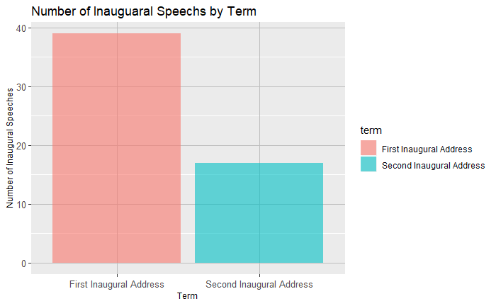

The chart below, shows how second speeches seem to be, in average, much shorter than first inaugural sepeches. Moreover, Second Inaugural Speeches show less variance than Firsts ones. It is important to take into account that the means presented are driven also by outliers on both ends: very short and very large speeches.

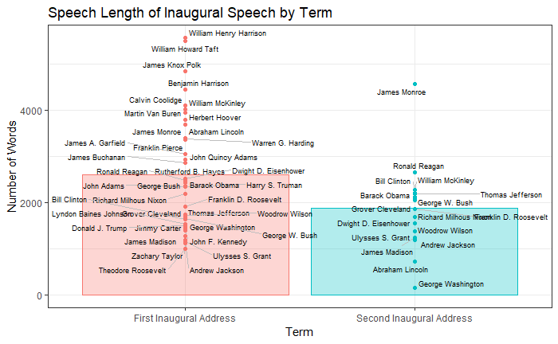

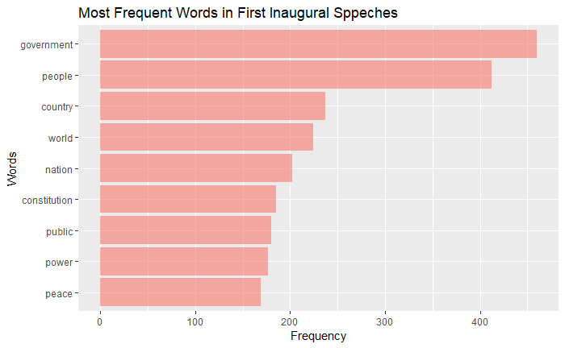

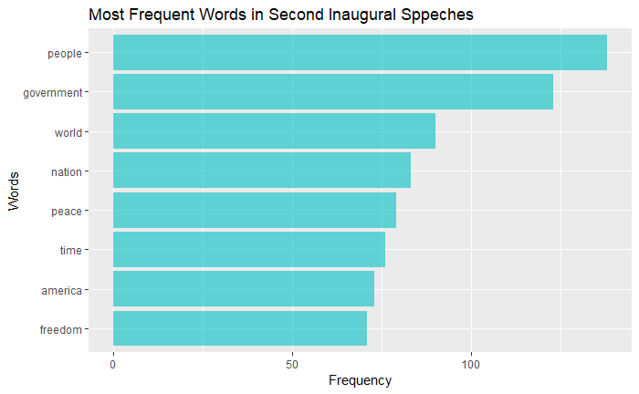

Now, using a tf-idf analysis, the most representative words of each group. The tf-idf, short for term frequency-inverse document frequency, is a numerical statistic that is intended to reflect how important a word is to a document in a collection or corpus.

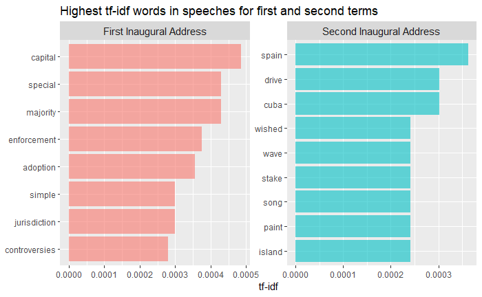

As it can see, the most representative words in the first term speeches refer to what can be classified as local affairs. The topics refer to law, capital, enforcement, democracy (*majorityy*/*controversies*). On the contrary, the most representative words in the second terms speeches refer foreign policy, making mentions of *Spain*, *Cuba*, and an *island*. Surprisingly, also “cultural-related” words like *paint* and *song* scored high. It might be the case that these words are used more in a figurative than in a literal way.

# Sentiment Analysis

Now, using sentiment dictionaries, the most frequent joy-related words are presented in the chart below.

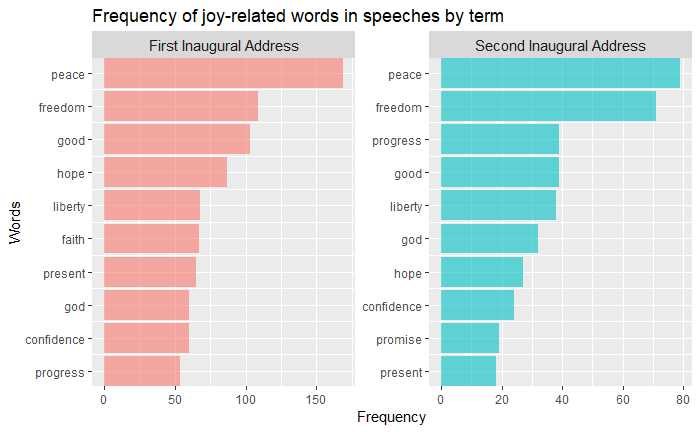

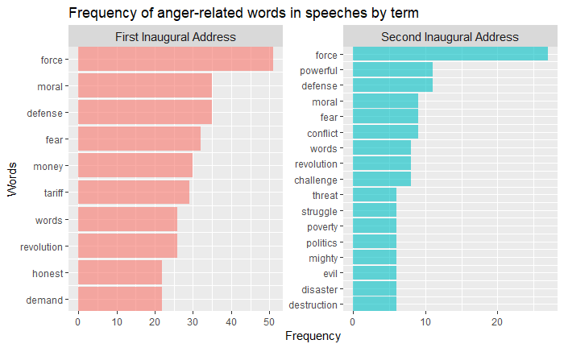

he first thing to notice is that the top ten anger related words in the second inaugural terms are much more diverse than in the firsts ones This might be due to the small sample of the second inaugural speeches, bur also might be an indication of Presidents using different words to express the same anger at different parts of their speeches, and justify their election for a second term. This theory is reinforced by the fact that in the second term speeches words like *conflict*, *challenge*, *threat*, and *struggle* appear among the ten most frequent words and not in the first term ones.

# Nouns - Verbs Analysis

After showing some differences in the words and emotions in both type of speeches, an analysis of the use of nouns and verbs in line with the research of Michal Reifen-Tagar and Orly Idan is provided below.

First, let’s make a general analysis of the groups. For this part of the analysis the *spacyr package* was used. *spacyr* is "an R wrapper to the Python (Cython) spaCy NLP system nicely integrated with quanteda. *spacyr* is designed to provide easy access to the powerful functionality of spaCy, in a simple format. This package, among other things, help to parse and tokenize documents, taging each token with its function as part of the speech (noun, verb, pronoun, adjective, etc.)

```r
sum(first_term_parsed$pos=="NOUN")/sum(table(first_term_parsed$pos))*100
```

```
[1] 23.49743
```

```r
sum(first_term_parsed$pos=="VERB")/sum(table(first_term_parsed$pos))*100
```

```
[1] 17.45025
```

```r
sum(second_term_parsed$pos=="NOUN")/sum(table(second_term_parsed$pos))*100
```

```
[1] 23.66317
```

```r
sum(second_term_parsed$pos=="VERB")/sum(table(second_term_parsed$pos))*100
```

```
[1] 17.87637
```

| term | share of nouns | share of verbs |
| --- | --- | --- |
| First Term | 23.49 | 17.45 |
| Second Term | 23.66 | 17.88 |

The table above shows that there is almost no difference between the share of nouns and share of verbs between the first and second term speeches. According to the theory of the authors on which this project is based, U.S. Presidents, in general, do not look to reduce tensions on their inaugural speeches more in one group than in other. Naturally, in both cases nouns exceed the number of verbs. However, when looking at specific presidents, this might be the case. In order to choose two pairs of cases two compare, I am going to make use of cosine similarites to find out two very similar speeches and two very different speeches. Afterwards, a similar noun-verb analysis will be provided.

```r
#Calculating cosine similarities for all documents
cosine_sim <- textstat_simil(dfm2, selection = NULL, method = "cosine", margin = "documents")
results <- (as.matrix(cosine_sim))
pairs <- subset(melt(results), value!=1)
pairs <- data.frame(t(apply(pairs, 1, sort)))
pairs <- unique(pairs)
pairs <- pairs [ ,c(3,2,1)]
names(pairs)<- c("Speech1", "Speech2", "Cosine Similarity")
pairs <- pairs[order(pairs$`Cosine Similarity`, decreasing = TRUE), ]
head(pairs, n=5)
```

|  | Speech1 | Speech2 | Cosine Similarity |
| --- | --- | --- | --- |
| 2624 | Ronald Reagan-Second Inaugural Address | Ronald Reagan-First Inaugural Address | 0.69210249 |
| 401 | James Monroe-Second Inaugural Address | James Monroe-First Inaugural Address | 0.68592860 |
| 2795 | Bill Clinton-Second Inaugural Address | Bill Clinton-First Inaugural Address | 0.65281676 |
| 2683 | Ronald Reagan-Second Inaugural Address | Bill Clinton-Second Inaugural Address | 0.65214344 |
| 3023 | Barack Obama-Second Inaugural Address | Barack Obama-First Inaugural Address | 0.64647759 |

```r
NA
```

[output not shown]

The first pair of very similar speeches that were not given by the same President is the one composed by Reagan’s Second Inaugural Address and Clinton’s second inaugural address. For the most disimilar speeches the Second Inaugural Address of George Washington, which has been the shortest address ever given, was removed since it was present among all pairs of top disimilar speeches. To pick a pair in which at least one contemporary President is present, I am going to pick the pair of Donald Trump’s first inaugural address and Andrew Jackson’s first inagural address.

For the most similar speeches, besides Reagan’s and Clinton’s second term speeches, I am going to add George W. Bush’s second address, since this one ocurred in the middle of the war on terror. For this last speech, a more conciliatory tone is expected, and for so, more use of nouns. For the most disimilar speeches, I am going to use Eisenhower’s second speech, two years after the Vietnam War began. A similar tone to Bush’s on his second term speech is expected.

| President_and_term | noun_verb_ratio |
| --- | --- |
| Reagan’s Second Inaugural Speech | 1.29 |
| Clinton’s Second Inaugural Speech | 1.53 |
| George W. Bush’s Second Inaugural Speech | 1.67 |

The table above shows that Clinton have a higher noun/verb ratio than Reagan on their second term speeches. This might be an indication of Clinton being more conciliatory/calling for unit than Reagan. However, George W. Bush in his second term speech in 2005, was the one that reported the highest noun/verb ratio. This means that despite being in the middle of a War in Irak, Bush was using more nouns than presidents in relatively “calmer” years, probably aiming to obtain more support for his policies and foreign interventions.

Now let’s see the noun verb ratio for most disimilar speeches.

| President_and_term | noun_verb_ratio |
| --- | --- |
| Trumps’s First Inaugural Speech | 1.24 |
| Jackson’s First Inaugural Speech | 1.37 |
| Eisenhower’s Second Inaugural Speech | 1.45 |

# Word2Vec/GloVe

After creating the vocabulary, the vectorization can take place. The skip-gram algorithm from the Word2Vec package with a window of plus minus 5 words from the target word will be used. Once the vectors are ready, we can use them to identify the words that are close to others. It is important to metion that this is determined, again, by a cosine similarity method.

```r
head(sort(cos_sim_first[,1], decreasing = T), 10)
```

```
  government       people          can      federal       states          may        union         self         upon constitution
   1.0000000    0.4715703    0.4011550    0.3668242    0.3658887    0.3512965    0.3265139    0.3236789    0.3152142    0.3113591
```

In the table above, it can be seen that the word that appears more in the context of *government* is *people*, followed by words that alude to the type structure of the government: *federal* and *states*. Now let’s do the same for second term speeches. It is important to notice the presence of two verbs: *can* and *may*.

```r
gov = second_word_vectors["government", , drop=F]
cos_sim_second = sim2(x = second_word_vectors, y = gov, method = "cosine", norm = "l2")
head(sort(cos_sim_second[,1], decreasing = T), 10)
```

[output not shown]

For the second term speeches, the words that appear in the context of *government* are different than in the first term speeches. In this case, also two verbs appear: *must* and *can*. The verb *must* is a stronger verb than *may*, present in the first term speeches. This migh be an indication that in second term speeches, U.S. Presidents might be less worried about releasing tension among citizens than in first term speeches when it come to governmental plans and actions.

# Conclusions and Ethics Discussion

Regarding ethical considerations, it is important to mention that NLP techniques must be used carefully. Particularly, when studying large periods of time, researches must take into account the context in which different words and framings were used. When finding similar and disimilar speeches, a closer look should be made since actually different expressions and words might be more similar than what these processes might report. NLP methods cannot make this work for humans, at least for now. NLP catches up patterns and relations that reflect societal biases at different points in time. In this particular case, when a word was categorized as one that provoked negative or positive feelings, it was only based on a contemporary interpreation of the word and without the sensitivity that context and a deeper qualitative investigation can provide. Nevertheless, this NLP approach for the study of political communications in time can save resources when starting an investigation by providing initial clues on where starting to look.